# Le format GPX

## Introduction

GPX (*GPS eXchange Format*) est un format de fichier XML permettant l’échange de coordonnées GPS. Ce format permet de décrire une collection de points utilisables sous forme de point de cheminement (*waypoint*), trace (*track*) ou itinéraire (*route*). C’est un format de fichier ouvert.

Liens :

- Format GPX (fr.wikipedia.org)
- [Description du standard](http://www.topografix.com/gpx.asp)
- [Visualisation de traces GPX](http://www.visugpx.com/)

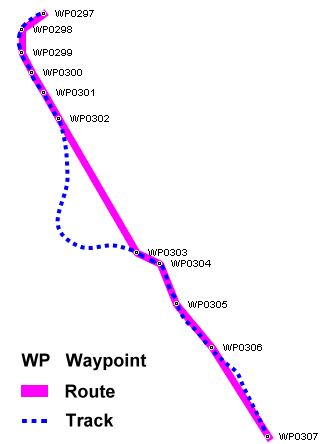

## Structure

Chaque liste peut être décrite par des caractéristiques supplémentaires : un horodatage (`<time>`), l’altitude en mètres (`<ele>`), un nom (`<name>`), …

Les balises `<wpt>`, `<rte>` et `<trk>` possèdent deux attributs : `lat` et `lon` pour la localisation (en degrés décimaux, WGS84).

Exemple :

```xml
<?xml version="1.0" encoding="UTF-8" standalone="no" ?>
<gpx xmlns="http://www.topografix.com/GPX/1/1" creator="byHand" version="1.1"
    xmlns:xsi="http://www.w3.org/2001/XMLSchema-instance"
    xsi:schemaLocation="http://www.topografix.com/GPX/1/1 http://www.topografix.com/GPX/1/1/gpx.xsd">

  <wpt lat="39.921055008" lon="3.054223107">
    <ele>12.863281</ele>
    <time>2005-05-16T11:49:06Z</time>
    <name>Cala Sant Vicenç - Mallorca</name>
    <sym>City</sym>
  </wpt>
</gpx>
```

## Autres formats

Les formats sont souvent propriétaires et spécifiques à une marque et aux logiciels associés (Navteq, Tele Atlas, ViaMichelin) :

- CSV : Garmin, Navman, Navigon (il n’y a pas de norme ici pour le CSV)
- OV2 : TomTom, CoPilot Live
- GPX : Garmin, GPSExchange, OziExplorer
- ASC : ViaMichelin
- [KML](https://fr.wikipedia.org/wiki/Keyhole_Markup_Language), KMZ : Google Earth, OziExplorer
- TRK : CompeGPS

*Remarque :* Les formats GPX et de [KML](https://fr.wikipedia.org/wiki/Keyhole_Markup_Language) sont devenus standard de l’*Open Geospatial Consortium*.

## Utilisation

En général, les applications permettent la conversion à partir du format GPX ou vers le format GPX. Certaines permettent aussi de télécharger ou de transmettre des données GPX à l’appareil GPS. Le protocole de communication à l’appareil GPS peut être standard (NMEA), de type RMC, ou propriétaire. Certains logiciels sont en outre capables de placer les points (POI) sur un fond de carte.

Quelques logiciels :

- GPSBabel : Outil de conversion entre différents formats de données GPS (Logiciel libre GPL)
- GPS Visualizer : Convertit en ligne un fichier de données GPS (différents formats) en GPX
- Site web OpenstreetMap (importation de traces)

## Travail demandé

- Récupérer le fichier GPX généré par l’application et tester le sur [www.visugpx.com](http://www.visugpx.com/).
- Vérifier la conversion en degré décimal des coordonnées latitude/longitude.
- Rechercher le format standardisé qui est utilisé pour représenter l’horodotage des données.

Retour au sommaire